# IF240 - Machine Learning and Deep Learning

## TP 3 - Support Vector Machines (SVM)

By Michaël Clément and Aurélie Bugeau (credits: Vincent Lepetit)

The main objectives of the TP are to:

- Apply linear and non-linear SVM classifiers on different datasets
- Learn how to optimize hyperparameters on a validation set

## 1. Datasets

We will use two classical synthetic datasets provided by `sklearn`: *moons* and *circles*.

```python
%matplotlib inline
import matplotlib.pyplot as plt
import numpy as np
from sklearn.datasets import make_moons, make_circles
```

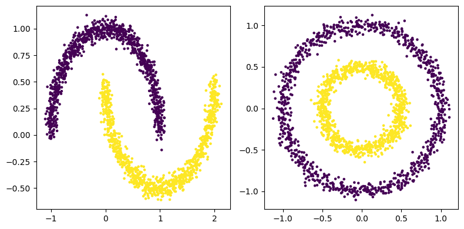

```python
#initialization of moons and circles set
X_moons, y_moons = make_moons(n_samples=2000, noise=0.05, random_state=42)
X_circles, y_circles = make_circles(n_samples=2000, factor=0.5, noise=0.05, random_state=42)

#plot the moons and circles set
plt.figure(figsize=(8, 4))
plt.subplot(121); plt.scatter(X_moons[:, 0], X_moons[:, 1], s=5, c=y_moons, cmap='viridis')
plt.subplot(122); plt.scatter(X_circles[:, 0], X_circles[:, 1], s=5, c=y_circles, cmap='viridis')
plt.tight_layout()
```

**(Question)** Explain what the variables `X_moons`, `y_moons`, `X_circles` and `y_circles` contain.

Les variables y_moons et y_circles sont des vecteurs contenant des 0 et des 1 correspondant aux labels, X_moons et X_circles sont des vecteurs contenant des vecteurs de 2 coordonnées correspondant à des points.

**(Question)** Separate the data into training, validation and test data.

```python
from sklearn.model_selection import train_test_split

# train : 0.8 (including validation : 0.2), test : 0.2

#Moons data
#separation of the data into training and test data
x_train_M, x_test_M, y_train_M, y_test_M = train_test_split(X_moons, y_moons, test_size=0.20)
#separation of the training data into training and validation data
x_train_M,x_val_M, y_train_M, y_val_M = train_test_split(x_train_M, y_train_M, test_size=0.2)

#Circles data
#separation of the data into training and test data
x_train_C, x_test_C, y_train_C, y_test_C = train_test_split(X_circles, y_circles, test_size=0.25)
#separation of the training data into training and validation data
x_train_C,x_val_C, y_train_C, y_val_C = train_test_split(x_train_C, y_train_C, test_size=0.2)
```

## 2. Linear SVM

**(Question)** Apply a linear SVM to the two training sets, and report the accuracy on the train, validation and test sets.

```python
from sklearn.svm import SVC

#accuracy score function
def accuracy_score(y_test,y_pred) :
    good = 0
    for i in range(len(y_test)):
        if y_test[i] == y_pred[i]:
            good += 1
    return good / len(y_test)

def print_results(model, x_train, y_train, x_test, y_test, x_val, y_val) :
    y_pred_train = model.predict(x_train)
    # accuracy score of prediction on training data
    print("training set score : {:.2f}".format(accuracy_score(y_train, y_pred_train)))

    y_pred_test = model.predict(x_test)
    # accuracy score of prediction on test data
    print("testing set score : {:.2f}".format(accuracy_score(y_test,y_pred_test)))

    y_pred_val= model.predict(x_val)
    # accuracy score of prediction on validation data
    print("validation set score : {:.2f}".format(accuracy_score(y_val,y_pred_val)))

#moons dataset
print("*** Moon ***")
m_svc = SVC(kernel='linear', C = 1.0)
m_svc.fit(x_train_M,y_train_M)

print_results(m_svc, x_train_M, y_train_M, x_test_M, y_test_M, x_val_M, y_val_M)

#circles dataset
print("*** Circle ***")
c_svc = SVC(kernel='linear', C = 100.0)
c_svc.fit(x_train_C,y_train_C)

print_results(c_svc, x_train_C, y_train_C, x_test_C, y_test_C, x_val_C, y_val_C)

#y_pred = m_svc.predict(x_test_M)
```

```
*** Moon ***
training set score : 0.89
testing set score : 0.87
validation set score : 0.88
*** Circle ***
training set score : 0.54
testing set score : 0.53
validation set score : 0.52
```

**(Question)** Study the influence of the hyperparameter $C$ controling the balance between the loss function and the regularization term. Use the validation sets to identify an optimal value for $C$ and report the accuracy on train, validation and test sets.

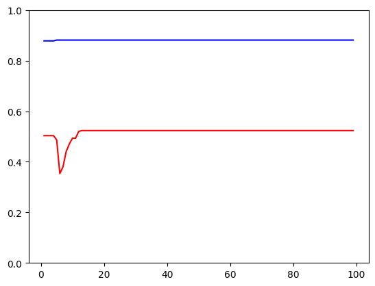

```python
#variation of C hyperparameter and its effect on accuracy on train, validation and test sets
m_score = np.empty(99)
c_score = np.empty(99)
for i in range(1,100) :
    moon_svc = SVC(kernel='linear', C = i)
    moon_svc.fit(x_train_M,y_train_M)
    y_pred_val_M = moon_svc.predict(x_val_M)
    m_score[i-1] = accuracy_score(y_val_M,y_pred_val_M)

    circle_svc = SVC(kernel='linear', C = i)
    circle_svc.fit(x_train_C,y_train_C)
    y_pred_val_C = circle_svc.predict(x_val_C)
    c_score[i-1] = accuracy_score(y_val_C,y_pred_val_C)
x_plt = [i for i in range(1,100)]

plt.ylim(0, 1)
plt.plot(x_plt,m_score, 'b', x_plt, c_score, 'r')
```

**(Question)** Analyze and explain the results.

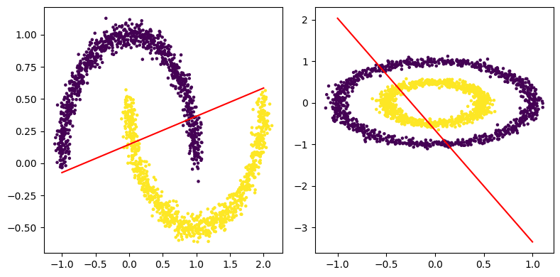

```python
plt.figure(figsize=(8, 4))
plt.subplot(121); plt.scatter(X_moons[:, 0], X_moons[:, 1], s=5, c=y_moons, cmap='viridis')

m_svc = SVC(kernel='linear', C = 1.0)
m_svc.fit(x_train_M,y_train_M)

w = m_svc.coef_[0]
b = m_svc.intercept_[0]
x_points_m = np.linspace(-1, 2)
y_points_m = -(w[0] / w[1]) * x_points_m - b / w[1]
plt.plot(x_points_m, y_points_m, c='r');

plt.subplot(122); plt.scatter(X_circles[:, 0], X_circles[:, 1], s=5, c=y_circles, cmap='viridis')

c_svc = SVC(kernel='linear', C = 100.0)
c_svc.fit(x_train_C,y_train_C)

w = c_svc.coef_[0]
b = c_svc.intercept_[0]
x_points_c = np.linspace(-1.0, 1.0)
y_points_c = -(w[0] / w[1]) * x_points_c - b / w[1]
plt.plot(x_points_c, y_points_c, c='r');

plt.tight_layout()
```

Now, we are going to visualize the results.

**(Question)** Explain what the following code is doing:

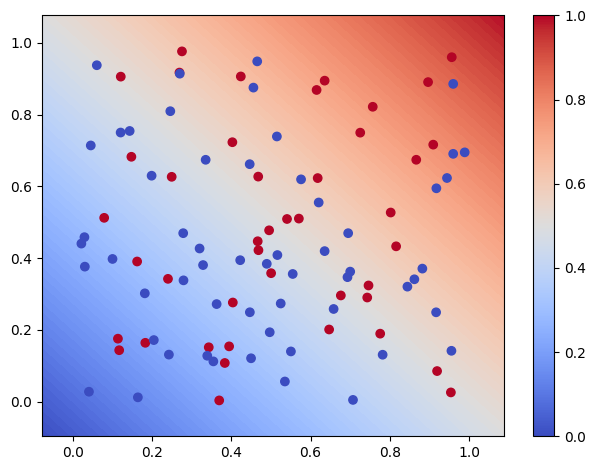

```python
X = np.random.rand(100, 2)
y = np.random.randint(0, 2, size=100)

pad, num = 0.1, 100
x1_min, x1_max = X[:, 0].min()-pad, X[:, 0].max()+pad
x2_min, x2_max = X[:, 1].min()-pad, X[:, 1].max()+pad
xx1, xx2 = np.meshgrid(np.linspace(x1_min, x1_max, num=num),
                       np.linspace(x2_min, x2_max, num=num))
X_mesh = np.stack((xx1.reshape(-1), xx2.reshape(-1)), axis=1)

Z = 1. * xx1.reshape(-1) + 1. * xx2.reshape(-1)
Z = Z.reshape(xx1.shape)

plt.contourf(xx1, xx2, Z, levels=100, cmap='coolwarm')
plt.scatter(X[:, 0], X[:, 1], c=y, cmap='coolwarm')
plt.colorbar()
plt.tight_layout()
```

[output not shown]

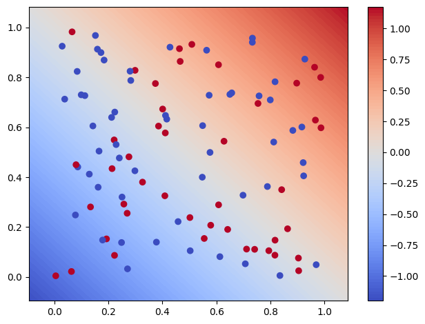

```python
#exemple de meshgrid
X = np.random.rand(100, 2) # points de dim 2
y = np.random.randint(0, 2, size=100) # soit 0 soit 1
print(X.shape)
print(y.shape)
pad, num = 0.1, 100
x1_min, x1_max = X[:, 0].min()-pad, X[:, 0].max()+pad
x2_min, x2_max = X[:, 1].min()-pad, X[:, 1].max()+pad
xx1, xx2 = np.meshgrid(np.linspace(x1_min, x1_max, num=num),
                       np.linspace(x2_min, x2_max, num=num))
print(xx1.shape, xx2.shape)
X_mesh = np.stack((xx1.reshape(-1), xx2.reshape(-1)), axis=1)
print(X_mesh.shape)
Z = 1 * xx1.reshape(-1) + 1. * xx2.reshape(-1)-1
print(Z.shape)
Z = Z.reshape(xx1.shape)
print(Z.shape)

plt.contourf(xx1, xx2, Z, levels=100, cmap='coolwarm') #fond
plt.colorbar()
plt.scatter(X[:, 0], X[:, 1], c=y, cmap='coolwarm') #points
plt.tight_layout()
```

Le code précédent initialise une matrice X qui contient 100 vecteurs de taille 2, correspondant à des coordonnées de points, et une matrice y correspond aux labels de chaque point de X, tous générés aléatoirement. Une meshgrid est créée, suivant le maximum et le minimum de la première colonne de X correspond aux abscisses des points et le maximum et le minimum a deuxième colonne de X correspondant aux ordonnées des points. Il y a donc deux matrices de taille 100x100 qui sont créées, avant que la fonction stack transforme ces deux matrices en une seule de taille 10000x2, puis on reforme une matrice de taille 100x100.

A la fin, on affiche les points de X de deux couleurs différentes suivant leur label. Le fond correspond à une couleur qui est plus ou moins intense suivant la distance à la droite de séparation.

**(Question)** Adapt the above code to display the dataset and the decision boundary of your SVM model, for both datasets.

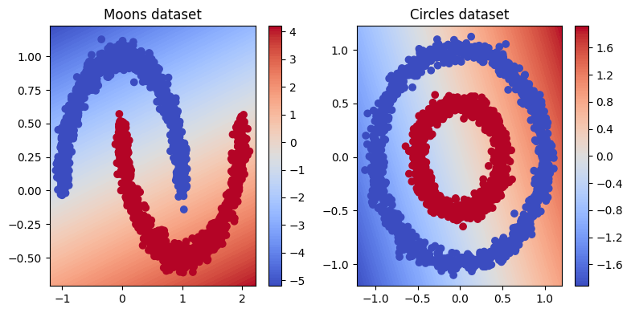

```python
# Create a mesh grid and compute the predictions of every point, for both models

#Moons
Xm,ym = make_moons(n_samples=2000, noise=0.05, random_state=42)

pad, num = 0.1, 100
x1m_min, x1m_max = Xm[:, 0].min()-pad, Xm[:, 0].max()+pad
x2m_min, x2m_max = Xm[:, 1].min()-pad, Xm[:, 1].max()+pad
xx1m, xx2m = np.meshgrid(np.linspace(x1m_min, x1m_max, num=num),
                       np.linspace(x2m_min, x2m_max, num=num))
Xm_mesh = np.stack((xx1m.reshape(-1), xx2m.reshape(-1)), axis=1)

# Circles
Xc,yc = make_circles(n_samples=2000, factor=0.5, noise=0.05, random_state=42)

pad, num = 0.1, 100
x1c_min, x1c_max = Xc[:, 0].min()-pad, Xc[:, 0].max()+pad
x2c_min, x2c_max = Xc[:, 1].min()-pad, Xc[:, 1].max()+pad
xx1c, xx2c = np.meshgrid(np.linspace(x1c_min, x1c_max, num=num),
                       np.linspace(x2c_min, x2c_max, num=num))
Xc_mesh = np.stack((xx1c.reshape(-1), xx2c.reshape(-1)), axis=1)

plt.figure(figsize=(8, 4))
plt.subplot(121)
plt.title('Moons dataset')
# Plot the test set of the moons dataset on top of the decision boundary
w1 = m_svc.coef_[0][0]
w2 = m_svc.coef_[0][1]

Z = w1 * xx1m.reshape(-1) + w2 * xx2m.reshape(-1)
Z = Z.reshape(xx1m.shape)

plt.contourf(xx1m, xx2m, Z, levels=100, cmap='coolwarm')
plt.colorbar()
plt.scatter(Xm[:, 0], Xm[:, 1], c=ym, cmap='coolwarm')

plt.subplot(122)
plt.title('Circles dataset')
# Plot the test set of the circles dataset on top of the decision boundary
w1 = c_svc.coef_[0][0]
w2 = c_svc.coef_[0][1]

Z = w1 * xx1c.reshape(-1) + w2 * xx2c.reshape(-1)
Z = Z.reshape(xx1c.shape)

plt.contourf(xx1c, xx2c, Z, levels=100, cmap='coolwarm')
plt.colorbar()
plt.scatter(Xc[:, 0], Xc[:, 1], c=yc, cmap='coolwarm')

plt.tight_layout()
```

**(Question)** Analyze the results. What can you conclude?

Dans le cas du dataset moon, la classification linéaire est assez efficace, mais elle n'est pas efficace dans le cas du dataset des cercles.

## 3. Non-Linear SVM

Now, we experiment non-linear SVM classifiers with different kernels. We will focus on gaussian (RBF) and polynomial kernels.

**(Question)** Train non-linear SVM classifiers with gaussian and polynomial kernels for both datasets. Report the accuracy for the train, validation and test sets. Show the results and the decision boundaries.

### Gaussian SVM classifier for moon training set

```
training set score : 1.00
testing set score : 1.00
validation set score : 1.00
```

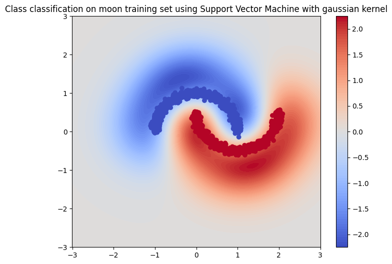

```python
# gaussian SVM classifier for moon training set
clf1 = SVC(kernel="rbf")
clf1.fit(x_train_M, y_train_M)

plt.figure(figsize=(8, 6))
xx, yy = np.meshgrid(np.linspace(-3, 3, 200), np.linspace(-3, 3, 200))

# evaluate decision function in a grid
Z = clf1.decision_function(np.c_[xx.ravel(), yy.ravel()])
Z = Z.reshape(xx.shape)

plt.contourf(xx, yy, Z, levels=100, cmap='coolwarm')
plt.colorbar()
plt.scatter(x_train_M[:, 0], x_train_M[:, 1], c=y_train_M, cmap='coolwarm')#points
plt.title("Class classification on moon training set using Support Vector Machine with gaussian kernel")

print_results(clf1, x_train_M, y_train_M, x_test_M, y_test_M, x_val_M, y_val_M)
```

### Poly SVM classifier for moon training set

```
training set score : 0.94
testing set score : 0.93
validation set score : 0.93
```

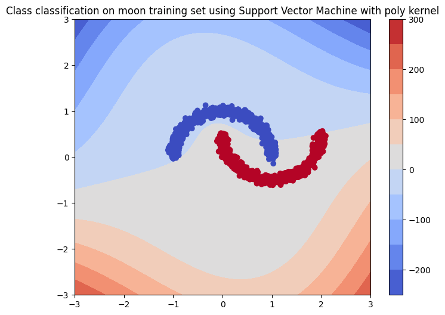

```python
# poly SVM classifier for moon training set
clf2 = SVC(kernel="poly")
clf2.fit(x_train_M, y_train_M)

plt.figure(figsize=(8, 6))
xx, yy = np.meshgrid(np.linspace(-3, 3, 200), np.linspace(-3, 3, 200))

# evaluate decision function in a grid
Z = clf2.decision_function(np.c_[xx.ravel(), yy.ravel()])
Z = Z.reshape(xx.shape)

plt.contourf(xx, yy, Z, levels=10, cmap='coolwarm')
plt.colorbar()
plt.scatter(x_train_M[:, 0], x_train_M[:, 1], c=y_train_M, cmap='coolwarm')#points
plt.title("Class classification on moon training set using Support Vector Machine with poly kernel")

print_results(clf2, x_train_M, y_train_M, x_test_M, y_test_M, x_val_M, y_val_M)
```

### Poly SVM classifier for circle training set

```
training set score : 0.72
testing set score : 0.70
validation set score : 0.69
```

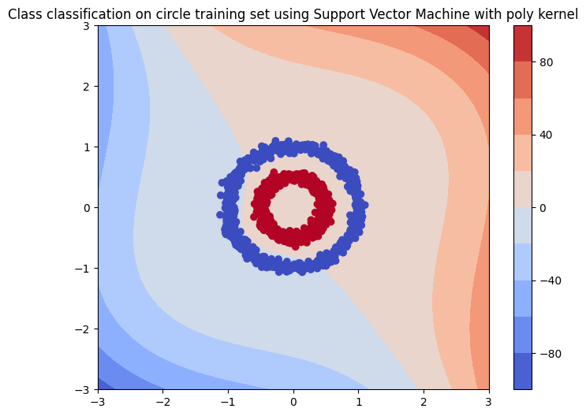

```python
# poly SVM classifier for circle training set
clf3 = SVC(kernel="poly")
clf3.fit(x_train_C, y_train_C)

plt.figure(figsize=(8, 6))
xx, yy = np.meshgrid(np.linspace(-3, 3, 200), np.linspace(-3, 3, 200))

# evaluate decision function in a grid
Z = clf3.decision_function(np.c_[xx.ravel(), yy.ravel()])
Z = Z.reshape(xx.shape)

plt.contourf(xx, yy, Z, levels=10, cmap='coolwarm')
plt.colorbar()
plt.scatter(x_train_C[:, 0], x_train_C[:, 1], c=y_train_C, cmap='coolwarm')#points
plt.title("Class classification on circle training set using Support Vector Machine with poly kernel")

print_results(clf3, x_train_C, y_train_C, x_test_C, y_test_C, x_val_C, y_val_C)
```

### Gaussian SVM classifier for circle training set

```
training set score : 1.00
testing set score : 1.00
validation set score : 1.00
```

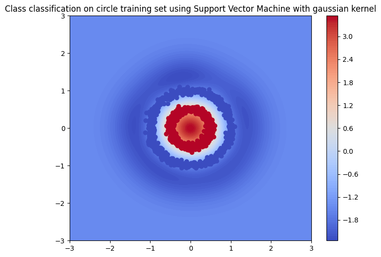

```python
# gaussian SVM classifier for circle training set
clf4 = SVC(kernel="rbf")
clf4.fit(x_train_C, y_train_C)

plt.figure(figsize=(8, 6))
xx, yy = np.meshgrid(np.linspace(-3, 3, 200), np.linspace(-3, 3, 200))

# evaluate decision function in a grid
Z = clf4.decision_function(np.c_[xx.ravel(), yy.ravel()])
Z = Z.reshape(xx.shape)

plt.contourf(xx, yy, Z, levels=100, cmap='coolwarm')
plt.colorbar()
plt.scatter(x_train_C[:, 0], x_train_C[:, 1], c=y_train_C, cmap='coolwarm')#points
plt.title("Class classification on circle training set using Support Vector Machine with gaussian kernel")

print_results(clf4, x_train_C, y_train_C, x_test_C, y_test_C, x_val_C, y_val_C)
```

**(Question)** Analyze and explain the results.

On peut voir que le kernel gaussien est très efficace sur le dataset des lunes et des cercles; puisque la prédiction est impeccable dans les deux cas.

**(Question)** Setup a proper validation (or cross-validation) protocol to optimize the hyperparameters of your models (note that the kernels also have their own hyperparameters). Report the accuracies, show the results and decision boundaries obtained.

*Remark*: it is possible (but **not mandatory**) to use tools such as `sklearn.model_selection.GridSearchCV`. But if you do so, make sure that you understand what you are doing!

### Moons data

```python
from sklearn.model_selection import GridSearchCV
import pandas as pd

#Moons data
x_train_M, x_test_M, y_train_M, y_test_M = train_test_split(X_moons, y_moons, test_size=0.20)

param_grid = {'C': [1, 10, 50, 100],
              'gamma': [1, 0.1, 0.01, 0.001, 0.0001],
              'kernel': ['rbf', 'poly']}

grid = GridSearchCV(SVC(), param_grid)

grid.fit(x_train_M, y_train_M)

res_m = pd.DataFrame(grid.cv_results_, columns=['rank_test_score', 'param_C', 'param_gamma', 'param_kernel','split0_test_score',
                                        'split1_test_score', 'split2_test_score', 'split3_test_score',
                                        'split4_test_score', 'mean_test_score', 'std_test_score'])

res_m.sort_values(by=['rank_test_score'])
```

|  | rank_test_score | param_C | param_gamma | param_kernel | split0_test_score | split1_test_score | split2_test_score | split3_test_score | split4_test_score | mean_test_score | std_test_score |
| --- | --- | --- | --- | --- | --- | --- | --- | --- | --- | --- | --- |
| 0 | 1 | 1 | 1 | rbf | 1.000000 | 1.000000 | 1.000000 | 1.000000 | 1.000000 | 1.000000 | 0.000000 |
| 32 | 1 | 100 | 0.1 | rbf | 1.000000 | 1.000000 | 1.000000 | 1.000000 | 1.000000 | 1.000000 | 0.000000 |
| 20 | 1 | 50 | 1 | rbf | 1.000000 | 1.000000 | 1.000000 | 1.000000 | 1.000000 | 1.000000 | 0.000000 |
| 10 | 1 | 10 | 1 | rbf | 1.000000 | 1.000000 | 1.000000 | 1.000000 | 1.000000 | 1.000000 | 0.000000 |
| 30 | 1 | 100 | 1 | rbf | 1.000000 | 1.000000 | 1.000000 | 1.000000 | 1.000000 | 1.000000 | 0.000000 |
| 22 | 6 | 50 | 0.1 | rbf | 1.000000 | 1.000000 | 1.000000 | 0.996875 | 1.000000 | 0.999375 | 0.001250 |
| 12 | 7 | 10 | 0.1 | rbf | 1.000000 | 0.993750 | 1.000000 | 0.993750 | 0.993750 | 0.996250 | 0.003062 |
| 31 | 8 | 100 | 1 | poly | 0.956250 | 0.934375 | 0.925000 | 0.943750 | 0.934375 | 0.938750 | 0.010570 |
| 11 | 8 | 10 | 1 | poly | 0.956250 | 0.934375 | 0.925000 | 0.943750 | 0.934375 | 0.938750 | 0.010570 |
| 21 | 8 | 50 | 1 | poly | 0.956250 | 0.934375 | 0.925000 | 0.943750 | 0.934375 | 0.938750 | 0.010570 |
| 1 | 11 | 1 | 1 | poly | 0.950000 | 0.934375 | 0.921875 | 0.943750 | 0.934375 | 0.936875 | 0.009561 |
| 23 | 12 | 50 | 0.1 | poly | 0.946875 | 0.928125 | 0.928125 | 0.940625 | 0.928125 | 0.934375 | 0.007906 |
| 33 | 13 | 100 | 0.1 | poly | 0.946875 | 0.928125 | 0.918750 | 0.940625 | 0.928125 | 0.932500 | 0.010000 |
| 2 | 14 | 1 | 0.1 | rbf | 0.915625 | 0.931250 | 0.893750 | 0.887500 | 0.896875 | 0.905000 | 0.016129 |
| 34 | 15 | 100 | 0.01 | rbf | 0.906250 | 0.915625 | 0.875000 | 0.875000 | 0.862500 | 0.886875 | 0.020387 |
| 24 | 16 | 50 | 0.01 | rbf | 0.903125 | 0.912500 | 0.875000 | 0.875000 | 0.862500 | 0.885625 | 0.018916 |
| 14 | 17 | 10 | 0.01 | rbf | 0.893750 | 0.906250 | 0.871875 | 0.871875 | 0.862500 | 0.881250 | 0.016178 |
| 36 | 18 | 100 | 0.001 | rbf | 0.893750 | 0.906250 | 0.871875 | 0.871875 | 0.859375 | 0.880625 | 0.016933 |
| 26 | 19 | 50 | 0.001 | rbf | 0.893750 | 0.906250 | 0.871875 | 0.871875 | 0.856250 | 0.880000 | 0.017744 |
| 38 | 20 | 100 | 0.0001 | rbf | 0.884375 | 0.881250 | 0.856250 | 0.859375 | 0.846875 | 0.865625 | 0.014658 |
| 16 | 20 | 10 | 0.001 | rbf | 0.884375 | 0.881250 | 0.856250 | 0.859375 | 0.846875 | 0.865625 | 0.014658 |
| 4 | 22 | 1 | 0.01 | rbf | 0.884375 | 0.881250 | 0.856250 | 0.856250 | 0.846875 | 0.865000 | 0.014974 |
| 28 | 23 | 50 | 0.0001 | rbf | 0.878125 | 0.868750 | 0.846875 | 0.850000 | 0.840625 | 0.856875 | 0.014170 |
| 18 | 24 | 10 | 0.0001 | rbf | 0.828125 | 0.834375 | 0.812500 | 0.821875 | 0.800000 | 0.819375 | 0.012087 |
| 6 | 24 | 1 | 0.001 | rbf | 0.828125 | 0.834375 | 0.812500 | 0.821875 | 0.800000 | 0.819375 | 0.012087 |
| 13 | 26 | 10 | 0.1 | poly | 0.790625 | 0.821875 | 0.850000 | 0.809375 | 0.803125 | 0.815000 | 0.020194 |
| 3 | 27 | 1 | 0.1 | poly | 0.728125 | 0.759375 | 0.793750 | 0.753125 | 0.721875 | 0.751250 | 0.025587 |
| 35 | 28 | 100 | 0.01 | poly | 0.643750 | 0.718750 | 0.771875 | 0.728125 | 0.696875 | 0.711875 | 0.041898 |
| 8 | 29 | 1 | 0.0001 | rbf | 0.790625 | 0.500000 | 0.500000 | 0.500000 | 0.500000 | 0.558125 | 0.116250 |
| 37 | 30 | 100 | 0.001 | poly | 0.643750 | 0.500000 | 0.500000 | 0.500000 | 0.500000 | 0.528750 | 0.057500 |
| 19 | 30 | 10 | 0.0001 | poly | 0.643750 | 0.500000 | 0.500000 | 0.500000 | 0.500000 | 0.528750 | 0.057500 |
| 27 | 30 | 50 | 0.001 | poly | 0.643750 | 0.500000 | 0.500000 | 0.500000 | 0.500000 | 0.528750 | 0.057500 |
| 25 | 30 | 50 | 0.01 | poly | 0.643750 | 0.500000 | 0.500000 | 0.500000 | 0.500000 | 0.528750 | 0.057500 |
| 17 | 30 | 10 | 0.001 | poly | 0.643750 | 0.500000 | 0.500000 | 0.500000 | 0.500000 | 0.528750 | 0.057500 |
| 15 | 30 | 10 | 0.01 | poly | 0.643750 | 0.500000 | 0.500000 | 0.500000 | 0.500000 | 0.528750 | 0.057500 |
| 9 | 30 | 1 | 0.0001 | poly | 0.643750 | 0.500000 | 0.500000 | 0.500000 | 0.500000 | 0.528750 | 0.057500 |
| 7 | 30 | 1 | 0.001 | poly | 0.643750 | 0.500000 | 0.500000 | 0.500000 | 0.500000 | 0.528750 | 0.057500 |
| 5 | 30 | 1 | 0.01 | poly | 0.643750 | 0.500000 | 0.500000 | 0.500000 | 0.500000 | 0.528750 | 0.057500 |
| 29 | 30 | 50 | 0.0001 | poly | 0.643750 | 0.500000 | 0.500000 | 0.500000 | 0.500000 | 0.528750 | 0.057500 |
| 39 | 30 | 100 | 0.0001 | poly | 0.643750 | 0.500000 | 0.500000 | 0.500000 | 0.500000 | 0.528750 | 0.057500 |

#### Accuracies on train and test dataset

```python
y_pred_train = grid.predict(x_train_M)
print("training set score : {:.2f}".format(accuracy_score(y_train_M, y_pred_train)))

y_pred_test = grid.predict(x_test_M)
print("testing set score : {:.2f}".format(accuracy_score(y_test_M,y_pred_test)))
```

```
training set score : 1.00
testing set score : 1.00
```

### Circle data

```python
x_train_C, x_test_C, y_train_C, y_test_C = train_test_split(X_circles, y_circles, test_size=0.25)

param_grid = {'C': [1, 10, 50, 100],
              'gamma': [1, 0.1, 0.01, 0.001, 0.0001],
              'kernel': ['rbf', 'poly']}

grid2 = GridSearchCV(SVC(), param_grid)

grid2.fit(x_train_C, y_train_C)

res_c = pd.DataFrame(grid2.cv_results_, columns=['rank_test_score', 'param_C', 'param_gamma', 'param_kernel','split0_test_score',
                                        'split1_test_score', 'split2_test_score', 'split3_test_score',
                                        'split4_test_score', 'mean_test_score', 'std_test_score'])

res_c.sort_values(by=['rank_test_score'])
```

|  | rank_test_score | param_C | param_gamma | param_kernel | split0_test_score | split1_test_score | split2_test_score | split3_test_score | split4_test_score | mean_test_score | std_test_score |
| --- | --- | --- | --- | --- | --- | --- | --- | --- | --- | --- | --- |
| 0 | 1 | 1 | 1 | rbf | 1.000000 | 1.000000 | 1.000000 | 1.000000 | 1.000000 | 1.000000 | 0.000000 |
| 22 | 1 | 50 | 0.1 | rbf | 1.000000 | 1.000000 | 1.000000 | 1.000000 | 1.000000 | 1.000000 | 0.000000 |
| 20 | 1 | 50 | 1 | rbf | 1.000000 | 1.000000 | 1.000000 | 1.000000 | 1.000000 | 1.000000 | 0.000000 |
| 30 | 1 | 100 | 1 | rbf | 1.000000 | 1.000000 | 1.000000 | 1.000000 | 1.000000 | 1.000000 | 0.000000 |
| 10 | 1 | 10 | 1 | rbf | 1.000000 | 1.000000 | 1.000000 | 1.000000 | 1.000000 | 1.000000 | 0.000000 |
| 32 | 1 | 100 | 0.1 | rbf | 1.000000 | 1.000000 | 1.000000 | 1.000000 | 1.000000 | 1.000000 | 0.000000 |
| 34 | 1 | 100 | 0.01 | rbf | 1.000000 | 1.000000 | 1.000000 | 1.000000 | 1.000000 | 1.000000 | 0.000000 |
| 12 | 1 | 10 | 0.1 | rbf | 1.000000 | 1.000000 | 1.000000 | 1.000000 | 1.000000 | 1.000000 | 0.000000 |
| 24 | 1 | 50 | 0.01 | rbf | 1.000000 | 1.000000 | 1.000000 | 1.000000 | 1.000000 | 1.000000 | 0.000000 |
| 2 | 1 | 1 | 0.1 | rbf | 1.000000 | 1.000000 | 1.000000 | 1.000000 | 1.000000 | 1.000000 | 0.000000 |
| 14 | 11 | 10 | 0.01 | rbf | 0.700000 | 0.753333 | 0.773333 | 0.740000 | 0.743333 | 0.742000 | 0.024000 |
| 21 | 12 | 50 | 1 | poly | 0.696667 | 0.673333 | 0.646667 | 0.680000 | 0.613333 | 0.662000 | 0.029181 |
| 31 | 13 | 100 | 1 | poly | 0.696667 | 0.666667 | 0.646667 | 0.680000 | 0.613333 | 0.660667 | 0.028783 |
| 11 | 14 | 10 | 1 | poly | 0.696667 | 0.663333 | 0.646667 | 0.680000 | 0.610000 | 0.659333 | 0.029769 |
| 1 | 15 | 1 | 1 | poly | 0.680000 | 0.606667 | 0.610000 | 0.676667 | 0.606667 | 0.636000 | 0.034603 |
| 33 | 16 | 100 | 0.1 | poly | 0.506667 | 0.510000 | 0.506667 | 0.653333 | 0.580000 | 0.551333 | 0.058180 |
| 36 | 17 | 100 | 0.001 | rbf | 0.506667 | 0.576667 | 0.623333 | 0.500000 | 0.540000 | 0.549333 | 0.045966 |
| 26 | 18 | 50 | 0.001 | rbf | 0.506667 | 0.633333 | 0.506667 | 0.486667 | 0.556667 | 0.538000 | 0.052982 |
| 23 | 19 | 50 | 0.1 | poly | 0.506667 | 0.506667 | 0.506667 | 0.546667 | 0.503333 | 0.514000 | 0.016384 |
| 4 | 20 | 1 | 0.01 | rbf | 0.506667 | 0.506667 | 0.506667 | 0.516667 | 0.503333 | 0.508000 | 0.004522 |
| 35 | 21 | 100 | 0.01 | poly | 0.506667 | 0.506667 | 0.506667 | 0.506667 | 0.503333 | 0.506000 | 0.001333 |
| 28 | 21 | 50 | 0.0001 | rbf | 0.506667 | 0.506667 | 0.506667 | 0.506667 | 0.503333 | 0.506000 | 0.001333 |
| 27 | 21 | 50 | 0.001 | poly | 0.506667 | 0.506667 | 0.506667 | 0.506667 | 0.503333 | 0.506000 | 0.001333 |
| 37 | 21 | 100 | 0.001 | poly | 0.506667 | 0.506667 | 0.506667 | 0.506667 | 0.503333 | 0.506000 | 0.001333 |
| 29 | 21 | 50 | 0.0001 | poly | 0.506667 | 0.506667 | 0.506667 | 0.506667 | 0.503333 | 0.506000 | 0.001333 |
| 19 | 21 | 10 | 0.0001 | poly | 0.506667 | 0.506667 | 0.506667 | 0.506667 | 0.503333 | 0.506000 | 0.001333 |
| 38 | 21 | 100 | 0.0001 | rbf | 0.506667 | 0.506667 | 0.506667 | 0.506667 | 0.503333 | 0.506000 | 0.001333 |
| 18 | 21 | 10 | 0.0001 | rbf | 0.506667 | 0.506667 | 0.506667 | 0.506667 | 0.503333 | 0.506000 | 0.001333 |
| 17 | 21 | 10 | 0.001 | poly | 0.506667 | 0.506667 | 0.506667 | 0.506667 | 0.503333 | 0.506000 | 0.001333 |
| 16 | 21 | 10 | 0.001 | rbf | 0.506667 | 0.506667 | 0.506667 | 0.506667 | 0.503333 | 0.506000 | 0.001333 |
| 15 | 21 | 10 | 0.01 | poly | 0.506667 | 0.506667 | 0.506667 | 0.506667 | 0.503333 | 0.506000 | 0.001333 |
| 13 | 21 | 10 | 0.1 | poly | 0.506667 | 0.506667 | 0.506667 | 0.506667 | 0.503333 | 0.506000 | 0.001333 |
| 9 | 21 | 1 | 0.0001 | poly | 0.506667 | 0.506667 | 0.506667 | 0.506667 | 0.503333 | 0.506000 | 0.001333 |
| 8 | 21 | 1 | 0.0001 | rbf | 0.506667 | 0.506667 | 0.506667 | 0.506667 | 0.503333 | 0.506000 | 0.001333 |
| 7 | 21 | 1 | 0.001 | poly | 0.506667 | 0.506667 | 0.506667 | 0.506667 | 0.503333 | 0.506000 | 0.001333 |
| 6 | 21 | 1 | 0.001 | rbf | 0.506667 | 0.506667 | 0.506667 | 0.506667 | 0.503333 | 0.506000 | 0.001333 |
| 5 | 21 | 1 | 0.01 | poly | 0.506667 | 0.506667 | 0.506667 | 0.506667 | 0.503333 | 0.506000 | 0.001333 |
| 3 | 21 | 1 | 0.1 | poly | 0.506667 | 0.506667 | 0.506667 | 0.506667 | 0.503333 | 0.506000 | 0.001333 |
| 25 | 21 | 50 | 0.01 | poly | 0.506667 | 0.506667 | 0.506667 | 0.506667 | 0.503333 | 0.506000 | 0.001333 |
| 39 | 21 | 100 | 0.0001 | poly | 0.506667 | 0.506667 | 0.506667 | 0.506667 | 0.503333 | 0.506000 | 0.001333 |

**(Question)** Explain what you did. Analyze and explain the results.

Pour chaque paramètre et valeurs associées présents dans la variable param_grid, des entrainements sont réalisées afin de tester toutes les combinaisons de valeurs données.  
De plus pour chacunes de ces combinaisons d'hyperparamètres 5 entrainements sont réalisés. En effet, les données d'entrainements sont divisées en 5 parties puis pour chaque entrainement une partie est utilisée pour la validation et les 4 autres pour l'entrainement. La partie utilisée pour la validation change à chaque entrainement de manière à pouvoir tester toutes les données d'entrainement sans qu'elles soient utilisées pour l'entrainement au moment de leur utilisation en tant que données de validation. Une moyenne de l'accuracy des 5 entrainements est réalisée pour avoir un classement.

- C=1 et gamma =1
- C=1 et gamma =0.1
- C=50 et gamma = 1
- C=50 et gamma = 0.01
- C=10 et gamma = 0.1
- C=10 et gamma = 1
- C=100 et gamma = 1
- C=100 et gamma = 0.1
- C=50 et gamma = 0.1
- C=100 et gamma = 0.01